# Final Project Proposal

National Park Species

Moriah Ruggerio

# Import the data:

```r
most_visited_nps_species_data <- readr::read_csv('https://raw.githubusercontent.com/rfordatascience/tidytuesday/main/data/2024/2024-10-08/most_visited_nps_species_data.csv')
most_visited_nps_species_data_cleaned <- most_visited_nps_species_data %>%
  janitor::clean_names()
```

Determine what variables to remove to keep it between 10-20:

```r
most_visited_nps_species_data_cleaned <- most_visited_nps_species_data_cleaned %>%
  filter(taxon_record_status == "Active", park_accepted == TRUE) %>%  #only includes data with active taxons, and accepted in park status
  #count(taxon_record_status)
  select(park_name:family, sci_name, common_names, occurrence:abundance, references:vouchers, te_status:s_rank) #%>% # removes empty and exluded rows to keep the variables within range
  #count(taxon_record_status, park_accepted)

#no data in synonyms, external_links
#all data is not sensitive (remove variable)
#combine nativeness_tabs with native & same with occurrence and occurrence_tags
#remove park_tags
#remove inactive taxons (including data rows)
#only include park accepted/remove the row and record status
```

```r
write_csv(most_visited_nps_species_data_cleaned, file = "data/most_visited_nps_species_data_cleaned.csv")
```

```r
most_visited_nps_species_data_cleaned %>%
  count(nativeness)
```

| nativeness | n |
| --- | --- |
| Native | 24916 |
| Non-native | 3754 |
| Unknown | 25085 |
| NA | 1287 |

# Introduction

This project uses the dataset `most_visited_nps_species_data_cleaned`. The National Park Service (NPS) keeps a list of every species found within each national park. The data used in this project is originally from the National Park Species List. It can be accessed here: https://irma.nps.gov/NPSpecies/Search/SpeciesList. Due to the massive size of this dataset, it was restricted to the top 15 most popular national parks by `f. hull` in the `tidytuesday` git repository on September 2, 2024. This reduced dataset (`most_visited_nps_species_data`) was accessed on March 15, 2025 from https://github.com/rfordatascience/tidytuesday/blob/main/data/2024/2024-10-08/readme.md. Since this dataset originally had too many for the confines of this assignment, I restricted the scope of the data further. Only included in this projects’ dataset (`most_visited_nps_species_data_cleaned`) are species whose presence in the park has been approved by the NPS, have an active taxon (current scientific name), and a non-sensitive species status. Data on sensitive species is removed from all public access by the NPS to protect endangered or fragile species in national parks.

The dataset has 55042 rows and 19 variables. Each row is a specific species found in one of the parks. The variables are `park_name`, `category_name`, `order`, `family`, `sci_name`, `common_names`, `occurrence`, `occurrence_tags`, `nativeness`, `nativeness_tags`, `abundance`, `references`, `observations`, `vouchers`, `te_status`, `state_status`, `ozone_sensitive_status`, `g_rank`, `s_rank`. (See `README.md` for variable descriptions. The intent of this research project is to examine if there is trends between biodiversity and the popularity of a park. Some specific research questions to be examined are: (1) Do more popular parks have higher observations of birds (and other classes)? (2) Are there more native species seen in popular parks than invasives or introduced?

# Data

```r
glimpse(most_visited_nps_species_data_cleaned)
```

```
## Rows: 55,042
## Columns: 19
## $ park_name              <chr> "Acadia National Park", "Acadia National Park",…
## $ category_name          <chr> "Mammal", "Mammal", "Mammal", "Mammal", "Mammal…
## $ order                  <chr> "Artiodactyla", "Artiodactyla", "Carnivora", "C…
## $ family                 <chr> "Cervidae", "Cervidae", "Canidae", "Canidae", "…
## $ sci_name               <chr> "Alces alces", "Odocoileus virginianus", "Canis…
## $ common_names           <chr> "Moose", "Northern White-tailed Deer, Virginia …
## $ occurrence             <chr> "Present", "Present", "Present", "Unconfirmed",…
## $ occurrence_tags        <chr> NA, NA, NA, NA, NA, NA, NA, "Historical", NA, N…
## $ nativeness             <chr> "Native", "Native", "Non-native", "Native", "Un…
## $ nativeness_tags        <chr> NA, NA, NA, NA, NA, NA, NA, NA, NA, NA, NA, NA,…
## $ abundance              <chr> "Rare", "Abundant", "Common", NA, "Common", NA,…
## $ references             <dbl> 11, 20, 8, 2, 16, 1, 7, 10, 10, 5, 7, 6, 14, 1,…
## $ observations           <dbl> 1, 0, 1, 0, 0, 0, 0, 0, 0, 0, 1, 0, 1, 0, 0, 1,…
## $ vouchers               <dbl> 0, 0, 0, 0, 0, 0, 0, 0, 0, 0, 0, 0, 0, 0, 0, 0,…
## $ te_status              <chr> "50", "50", "SC", "E", NA, NA, "RT", NA, NA, NA…
## $ state_status           <chr> NA, NA, NA, NA, NA, "ME: SC", NA, NA, NA, NA, N…
## $ ozone_sensitive_status <chr> NA, NA, NA, NA, NA, NA, NA, NA, NA, NA, NA, NA,…
## $ g_rank                 <chr> "G5", "G5", "G5", "G5", "G5", "G5", "G5", "G5",…
## $ s_rank                 <chr> "ME: S5", "ME: S5", "ME: S5", "ME: SH", "ME: S5…
```

```r
skim(most_visited_nps_species_data_cleaned)
```

Data summary

| Name | most_visited_nps_species_… |
| --- | --- |
| Number of rows | 55042 |
| Number of columns | 19 |
| _______________________ |  |
| Column type frequency: |  |
| character | 16 |
| numeric | 3 |
| ________________________ |  |
| Group variables | None |

**Variable type: character**

| skim_variable | n_missing | complete_rate | min | max | empty | n_unique | whitespace |
| --- | --- | --- | --- | --- | --- | --- | --- |
| park_name | 0 | 1.00 | 18 | 35 | 0 | 15 | 0 |
| category_name | 0 | 1.00 | 4 | 21 | 0 | 16 | 0 |
| order | 556 | 0.99 | 5 | 22 | 0 | 501 | 0 |
| family | 642 | 0.99 | 6 | 24 | 0 | 2043 | 0 |
| sci_name | 0 | 1.00 | 3 | 69 | 0 | 38325 | 0 |
| common_names | 22731 | 0.59 | 3 | 218 | 0 | 21193 | 0 |
| occurrence | 122 | 1.00 | 7 | 16 | 0 | 4 | 0 |
| occurrence_tags | 53632 | 0.03 | 8 | 22 | 0 | 4 | 0 |
| nativeness | 1287 | 0.98 | 6 | 10 | 0 | 3 | 0 |
| nativeness_tags | 54921 | 0.00 | 8 | 17 | 0 | 4 | 0 |
| abundance | 13593 | 0.75 | 4 | 10 | 0 | 6 | 0 |
| te_status | 51367 | 0.07 | 1 | 6 | 0 | 18 | 0 |
| state_status | 52840 | 0.04 | 5 | 50 | 0 | 179 | 0 |
| ozone_sensitive_status | 54670 | 0.01 | 1 | 5 | 0 | 2 | 0 |
| g_rank | 19113 | 0.65 | 2 | 10 | 0 | 164 | 0 |
| s_rank | 30257 | 0.45 | 6 | 33 | 0 | 1271 | 0 |

**Variable type: numeric**

| skim_variable | n_missing | complete_rate | mean | sd | p0 | p25 | p50 | p75 | p100 | hist |
| --- | --- | --- | --- | --- | --- | --- | --- | --- | --- | --- |
| references | 0 | 1 | 1.19 | 2.06 | 0 | 0 | 1 | 2 | 88 | ▇▁▁▁▁ |
| observations | 0 | 1 | 7.15 | 119.04 | 0 | 0 | 0 | 0 | 11576 | ▇▁▁▁▁ |
| vouchers | 0 | 1 | 4.99 | 44.05 | 0 | 0 | 0 | 2 | 6931 | ▇▁▁▁▁ |

# Data Analysis Plan

*Predictor, Outcome Variables, and Comparison Groups:* (1) For the first question, the predictor variable will be `evidences` (sum of `observations`, `references`, and `vouchers`) while the outcome will be `park_name` (ordered as a factor by popularity). This will be compared across each `category_name`.

2. For the second question the predictor variable will be `nativeness` and the outcome vairable will be `park_name` (again ordered as a factor by park popularity).

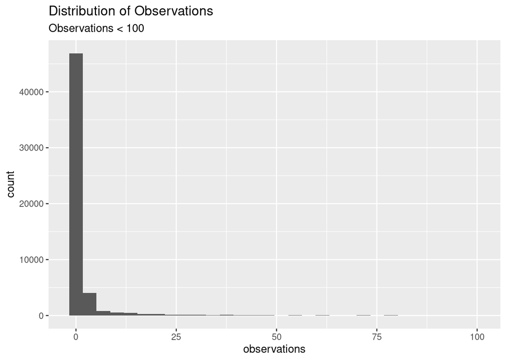

```r
most_visited_nps_species_data_cleaned %>%
  filter(observations < 100) %>% # split between 2 graphs as the data was too squished
  ggplot(aes(x = observations)) +
  geom_histogram() +
  ggtitle("Distribution of Observations") + labs(subtitle = "Observations < 100")
```

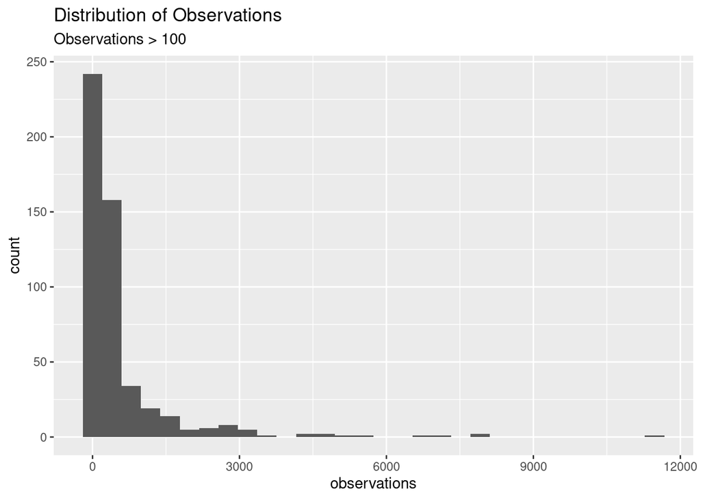

```r
most_visited_nps_species_data_cleaned %>%
  filter(observations > 100) %>%
  ggplot(aes(x = observations)) +
  geom_histogram() +
  ggtitle("Distribution of Observations") + labs(subtitle = "Observations > 100")
```

```r
most_visited_nps_species_data_cleaned %>%
  group_by(park_name, category_name) %>%
  summarise(sum(observations), sum(references), sum(vouchers, mean(observations), mean(references), mean(vouchers)))
```

| park_name | category_name | sum(observations) | sum(references) | sum(vouchers, mean(observations), mean(references), mean(vouchers)) |
| --- | --- | --- | --- | --- |
| Acadia National Park | Amphibian | 15 | 126 | 9.400000e+00 |
| Acadia National Park | Bird | 286 | 4279 | 1.254121e+01 |
| Acadia National Park | Fish | 1 | 106 | 1.000000e+01 |
| Acadia National Park | Mammal | 37 | 476 | 9.865385e+00 |
| Acadia National Park | Reptile | 5 | 70 | 6.818182e+00 |
| Acadia National Park | Vascular Plant | 1 | 4625 | 3.794914e+00 |
| Bryce Canyon National Park | Amphibian | 0 | 8 | 4.500000e+00 |
| Bryce Canyon National Park | Bird | 4 | 518 | 5.965596e+01 |
| Bryce Canyon National Park | Fish | 0 | 0 | 2.000000e+00 |
| Bryce Canyon National Park | Mammal | 1 | 573 | 8.213600e+02 |

[output cut: 128 more lines]

# Methods

To test my questions I first would need to convert `park_name` into a factor (ordered by popularity). Then I would need to create another variable `evidences` as the sum of `observations`, `references`, and `vouchers`. It may then be helpful to create a graphic and factor by `park_name` and compare the most commonly “evidenced” categories across each park. If data follows the hyposthesized patterns, for each category `evidences` will be higher in the most popular parks. I would also want to create graphics that look at the number of different species within each park. This would be grouped by `nativeness`. If the data follows the hypothesized assotiation, parks with higher ratios of nativness will be more popular.

```r
park_popularity <- c("Great Smoky Mountains", "Grand Canyon", "Zion", "Yellowstone", "Rocky Mountain", "Yosemite", "Acadia", "Grand Teton", "Joshua Tree", "Olympic", "Glacier", "Cuyahoga Valley", "Indiana Dunes", "Hot Springs", "Bryce Canyon")

#park attendance data from:
#  Ard, A. J. (2024, June 10). These are the top 15 most visited national parks in the U.S. see which ranked no. 1. USA Today. https://www.usatoday.com/picture-gallery/travel/news/2024/06/10/what-is-the-most-visited-national-park-in-the-us-see-the-top-15/74049474007/

most_visited_nps_species_data_cleaned <- most_visited_nps_species_data_cleaned %>%
  mutate(
    park_name = gsub("National Park", "", park_name), # removed "National Park" in park_name since it is redundant
    park_name = factor(park_name, labels = park_popularity) # creates a factor
    ) #%>%
  #count(park_name)       # checks order

most_visited_nps_species_data_cleaned %>%
  filter(!is.na(nativeness_tags))  # may want to combine nativeness with nativeness_tags
```

| park_name | category_name | order | family | sci_name | common_names | occurrence | occurrence_tags | nativeness | nativeness_tags | abundance | references | observations | vouchers | te_status | state_status | ozone_sensitive_status | g_rank | s_rank |
| --- | --- | --- | --- | --- | --- | --- | --- | --- | --- | --- | --- | --- | --- | --- | --- | --- | --- | --- |
| Great Smoky Mountains | Vascular Plant | Asparagales | Xanthorrhoeaceae | Hemerocallis fulva | Orange Daylily | Present | NA | Non-native | Cultivated | Unknown | 4 | 0 | 0 | NA | NA | NA | GNA | ME: SNA |
| Great Smoky Mountains | Vascular Plant | Asterales | Asteraceae | Helianthus annuus | Common Sunflower | Present | NA | Non-native | Cultivated | Unknown | 4 | 0 | 0 | NA | NA | NA | G5 | ME: SNA |
| Great Smoky Mountains | Vascular Plant | Boraginales | Boraginaceae | Symphytum officinale | Comfrey | Present | NA | Non-native | Cultivated | Unknown | 2 | 0 | 0 | NA | NA | NA | GNR | ME: SNA |
| Great Smoky Mountains | Vascular Plant | Brassicales | Brassicaceae | Alyssum alyssoides | Alyssum | Present | NA | Non-native | Cultivated | Unknown | 3 | 0 | 0 | NA | NA | NA | GNR | ME: SNA |
| Great Smoky Mountains | Vascular Plant | Brassicales | Brassicaceae | Armoracia rusticana | Horseradish | Present | NA | Non-native | Cultivated | Unknown | 4 | 0 | 0 | NA | NA | NA | GNR | ME: SNA |
| Great Smoky Mountains | Vascular Plant | Brassicales | Brassicaceae | Raphanus sativus | Garden Radish | Present | NA | Non-native | Cultivated | Unknown | 3 | 0 | 0 | NA | NA | NA | GNR | ME: SNA |
| Great Smoky Mountains | Vascular Plant | Caryophyllales | Amaranthaceae | Amaranthus hybridus | Green Amaranth, Pigweed | Present | NA | Non-native | Cultivated | Unknown | 2 | 0 | 0 | NA | NA | NA | G5? | ME: SNA |
| Great Smoky Mountains | Vascular Plant | Cornales | Cornaceae | Cornus sericea | Red-osier Dogwood | Present | NA | Non-native | Cultivated | Unknown | 3 | 0 | 0 | NA | NA | NA | G5 | ME: SNR |
| Great Smoky Mountains | Vascular Plant | Lamiales | Oleaceae | Ligustrum amurense | Amur Privet | Present | NA | Non-native | Cultivated | Unknown | 3 | 0 | 0 | NA | NA | NA | GNR | ME: SNA |
| Great Smoky Mountains | Vascular Plant | Lamiales | Oleaceae | Ligustrum vulgare | Common Privet | Present | NA | Non-native | Cultivated | Unknown | 2 | 0 | 0 | NA | NA | NA | GNR | ME: SNA |

[output cut: 111 more lines]

```r
most_visited_nps_species_data_cleaned <- most_visited_nps_species_data_cleaned%>%
  mutate(evidences = rowSums(across(c(vouchers, observations, references)), na.rm = TRUE))
```

```r
most_visited_nps_species_data_cleaned %>%
  count(category_name) %>%
  arrange(-n)
```

| category_name | n |
| --- | --- |
| Vascular Plant | 20529 |
| Insect | 12904 |
| Fungi | 5741 |
| Spider/Scorpion | 4650 |
| Bird | 4517 |
| Non-vascular Plant | 1753 |
| Mammal | 1072 |
| Other Non-vertebrates | 868 |
| Chromista | 756 |
| Fish | 614 |

[output cut: 6 more lines]

```r
most_visited_nps_species_data_cleaned %>%
  group_by(category_name) %>%
  summarise(sum_evidences = sum(evidences)) %>%
  arrange(-sum_evidences)
```

| category_name | sum_evidences |
| --- | --- |
| Vascular Plant | 276356 |
| Insect | 164753 |
| Bird | 149445 |
| Other Non-vertebrates | 33706 |
| Amphibian | 30387 |
| Fungi | 29170 |
| Mammal | 22021 |
| Spider/Scorpion | 7889 |
| Reptile | 5579 |
| Fish | 5263 |

[output cut: 6 more lines]

```r
most_visited_nps_species_data_cleaned %>%
  filter(category_name == "Vascular Plant")%>%
  group_by(park_name) %>%
  summarise(sum_evidences = sum(evidences)) %>%
  arrange(park_name)
```

| park_name | sum_evidences |
| --- | --- |
| Great Smoky Mountains | 4626 |
| Grand Canyon | 4248 |
| Zion | 4300 |
| Yellowstone | 4746 |
| Rocky Mountain | 1799 |
| Yosemite | 6146 |
| Acadia | 187853 |
| Grand Teton | 2254 |
| Joshua Tree | 3261 |
| Olympic | 7599 |

[output cut: 5 more lines]

```r
most_visited_nps_species_data_cleaned %>%
  group_by(category_name) %>%
  summarise(sum_observations = sum(observations)) %>%
  arrange(-sum_observations)
```

| category_name | sum_observations |
| --- | --- |
| Vascular Plant | 191097 |
| Bird | 132624 |
| Insect | 31009 |
| Amphibian | 13501 |
| Fungi | 6716 |
| Mammal | 6004 |
| Other Non-vertebrates | 4130 |
| Fish | 3520 |
| Reptile | 2908 |
| Spider/Scorpion | 677 |

[output cut: 6 more lines]

```r
#mutate nativeness -> native/non-native
#delete nativeness_tags -> invasive, native, non-native

most_visited_nps_species_data_cleaned <- most_visited_nps_species_data_cleaned%>%
  mutate(nativeness = if_else(nativeness == "Unknown", NA, nativeness)) #nativeness = if_else(nativeness_tags == "Invasive" | nativeness_tags == "Invasive, Noxious", "Invasive", nativeness)))             #will not use invasives since not enough present with the tag


most_visited_nps_species_data_cleaned %>%
  count(nativeness, park_name) %>%
  arrange(park_name)# look at types
```

| nativeness | park_name | n |
| --- | --- | --- |
| Native | Great Smoky Mountains | 1184 |
| Non-native | Great Smoky Mountains | 482 |
| NA | Great Smoky Mountains | 33 |
| Native | Grand Canyon | 1144 |
| Non-native | Grand Canyon | 98 |
| NA | Grand Canyon | 2 |
| Native | Zion | 1410 |
| Non-native | Zion | 283 |
| NA | Zion | 19 |
| Native | Yellowstone | 2139 |

[output cut: 35 more lines]

```r
number_nativness_df <-
  most_visited_nps_species_data_cleaned %>%
  group_by(park_name) %>%            # groups by park
  filter(!is.na(nativeness)) %>%     #removes NA
  select(park_name, category_name, nativeness) %>%
  count(nativeness) %>%
  mutate(native_percent = n / sum(n))
```

```r
number_nativness_df <-
  number_nativness_df %>%
  mutate(group = if_else(park_name =="Great Smoky Mountains" | park_name == "Grand Canyon" | park_name == "Zion" | park_name == "Yellowstone" | park_name == "Rocky Mountain", "top5",
                         if_else(park_name =="Glacier" | park_name == "Cuyahoga Valley" | park_name == "Indiana Dunes" | park_name == "Hot Springs" | park_name == "Bryce Canyon", "bottom5", "middle")))
```

```r
set.seed(221)
null_dist_nativeness <-
  number_nativness_df %>%
  filter(group != "middle", nativeness == "Non-native") %>%
 specify(response = native_percent, explanatory = group) %>%
 hypothesize(null = "independence") %>%
 generate(500, type = "bootstrap") %>%
 calculate(stat = "diff in means",
 order = c("bottom5", "top5"))
```

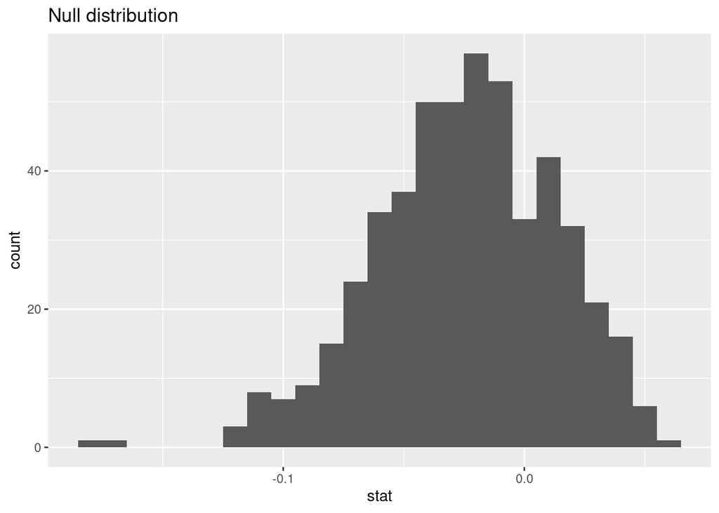

```r
ggplot(null_dist_nativeness, mapping = aes(x = stat)) +
 geom_histogram(binwidth = 0.01) +
 labs(title = "Null distribution")
```

```r
null_dist_nativeness %>%
 filter(stat > 0) %>%
 summarise(p_value = n()/nrow(null_dist_nativeness))
```

| p_value |
| --- |
| 0.274 |

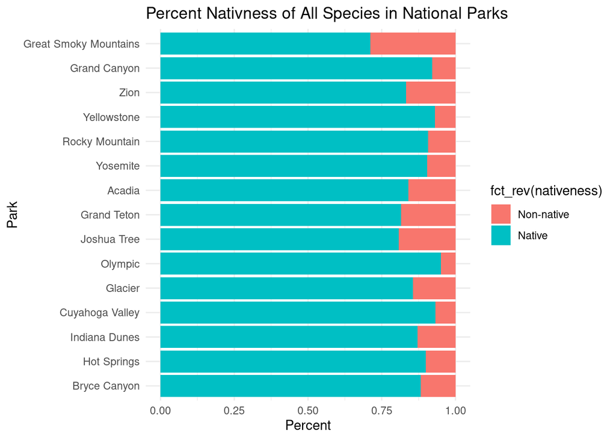

```r
most_visited_nps_species_data_cleaned %>%
  filter(!is.na(nativeness)) %>%
  ggplot(mapping = aes(y = fct_rev(park_name), #reverses order to put 1 on top
                       fill = fct_rev(nativeness))) +
  geom_bar(position = "fill") +
  labs(title = "Percent Nativness of All Species in National Parks", x = "Percent", y = "Park") +
  theme_minimal()
```

Look at top 3 categories of observations (Go back to observations not evidences)

```r
most_visited_nps_species_data_cleaned %>%
  filter(!park_name == "Acadia") %>%   #removes due to unusual amounts of insects
  group_by(category_name) %>%
  summarise(total_observations = sum(observations)) %>%
  arrange(-total_observations)
```

| category_name | total_observations |
| --- | --- |
| Bird | 48673 |
| Vascular Plant | 15099 |
| Mammal | 4868 |
| Reptile | 1392 |
| Amphibian | 801 |
| Fish | 527 |
| Insect | 9 |
| Non-vascular Plant | 7 |
| Chromista | 1 |
| Fungi | 1 |

[output cut: 6 more lines]

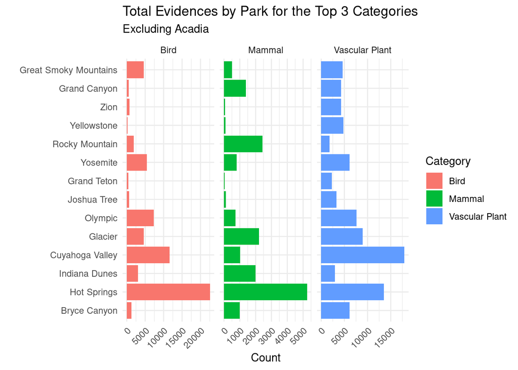

```r
most_visited_nps_species_data_cleaned %>%
  filter(category_name == "Bird" | category_name == "Vascular Plant" | category_name == "Mammal",
         !park_name == "Acadia") %>% #Acadia removed from graphic since the insect count was an outlier and scrunching the graph
  group_by(park_name, category_name) %>%
  summarize(total_evidences = sum(evidences, na.rm = TRUE)) %>%
  ggplot(mapping = aes(y = fct_rev(park_name), fill = category_name, x = total_evidences)) +
  geom_col() +
  facet_wrap(~category_name, scales = "free_x") +
  theme_minimal() +
  labs(title = "Total Evidences by Park for the Top 3 Categories", subtitle = "Excluding Acadia", x = "Count", y = "", fill = "Category") +
  theme(axis.text.x = element_text(angle = 45, hjust = 1))
```

Hypothesis testing evidences:

```r
observations_df <-
  most_visited_nps_species_data_cleaned %>%
  select(park_name, category_name, observations, evidences) %>% #selects only relevant categories
  filter(category_name == "Bird" | category_name == "Vascular Plant" | category_name == "Mammal") %>%
  group_by(category_name, park_name) %>%
  summarise(total_evidences = sum(evidences))
set.seed(144)
null_dist_observations_bird <-
  observations_df %>%
  filter(category_name == "Bird", park_name != "Acadia") %>%
   mutate(park_numeric = as.numeric(fct_inorder(park_name))) %>%
  specify(response = total_evidences, explanatory = as.numeric(park_numeric)) %>%
  hypothesize(null = "independence") %>%
  generate(reps = 500, type = "permute") %>%
  calculate(stat = "correlation")
```

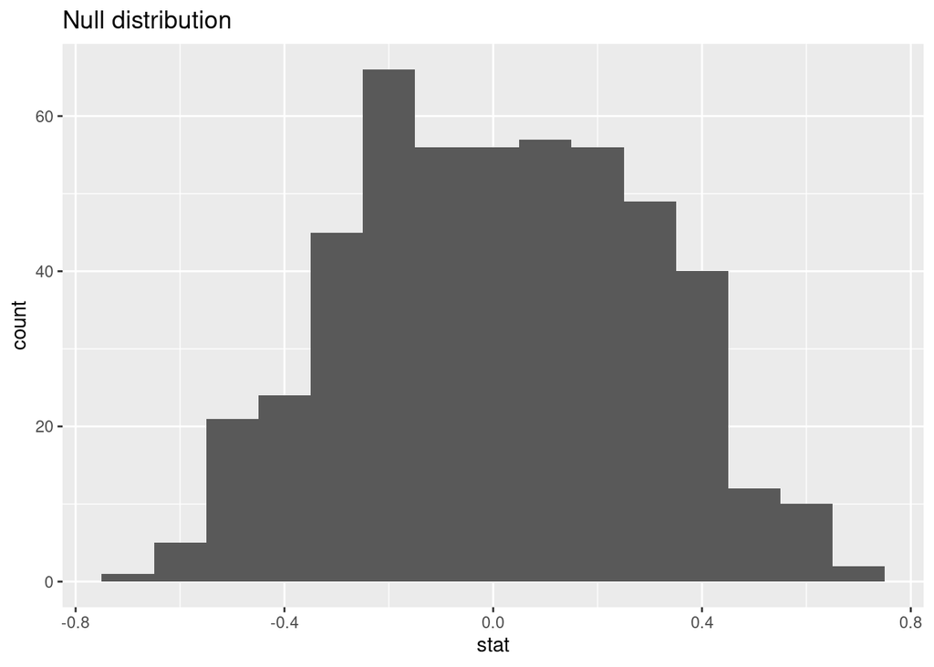

```r
ggplot(null_dist_observations_bird, mapping = aes(x = stat)) +
 geom_histogram(binwidth = 0.1) +
 labs(title = "Null distribution")
```

```r
null_dist_observations_bird %>%
 filter(stat > 0) %>%
 summarise(p_value = n()/nrow(null_dist_observations_bird))
```

| p_value |
| --- |
| 0.518 |

Mammals:

```r
set.seed(144)
null_dist_observations_mammals <-
  observations_df %>%
  filter(category_name == "Mammal", park_name != "Acadia") %>%
   mutate(park_numeric = as.numeric(fct_inorder(park_name))) %>%
  specify(response = total_evidences, explanatory = as.numeric(park_numeric)) %>%
  hypothesize(null = "independence") %>%
  generate(reps = 500, type = "permute") %>%
  calculate(stat = "correlation")
```

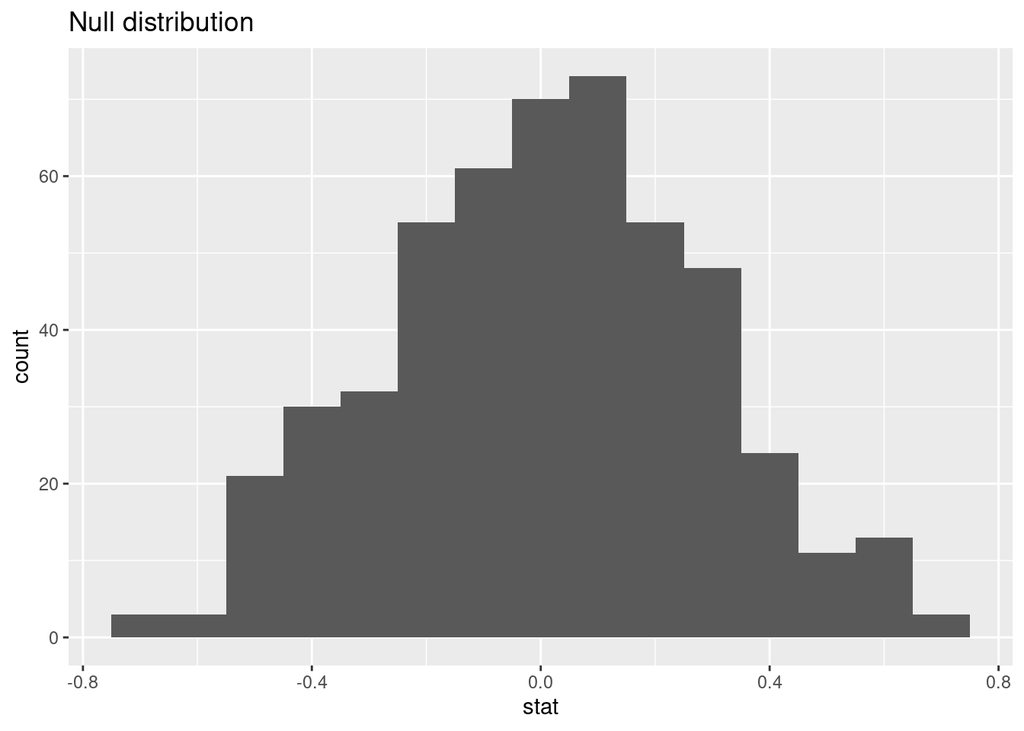

```r
ggplot(null_dist_observations_mammals, mapping = aes(x = stat)) +
 geom_histogram(binwidth = 0.1) +
 labs(title = "Null distribution")
```

```r
null_dist_observations_mammals %>%
 filter(stat > 0) %>%
 summarise(p_value = n()/nrow(null_dist_observations_mammals))
```

| p_value |
| --- |
| 0.528 |

Vascular Plants:

```r
set.seed(144)
null_dist_observations_plants <-
  observations_df %>%
  filter(category_name == "Vascular Plant", park_name != "Acadia") %>%
   mutate(park_numeric = as.numeric(fct_inorder(park_name))) %>%
  specify(response = total_evidences, explanatory = as.numeric(park_numeric)) %>%
  hypothesize(null = "independence") %>%
  generate(reps = 500, type = "permute") %>%
  calculate(stat = "correlation")
```

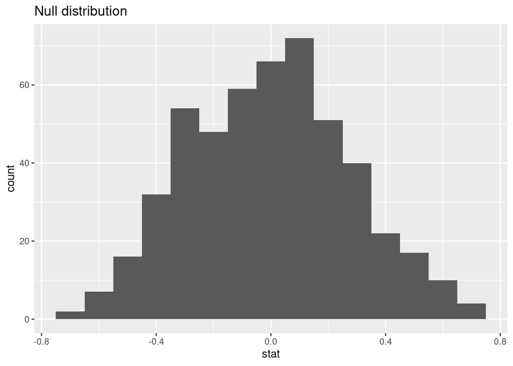

```r
ggplot(null_dist_observations_plants, mapping = aes(x = stat)) +
 geom_histogram(binwidth = 0.1) +
 labs(title = "Null distribution")
```

```r
null_dist_observations_plants %>%
 filter(stat > 0) %>%
 summarise(p_value = n()/nrow(null_dist_observations_plants))
```

| p_value |
| --- |
| 0.508 |

```r
write_csv(most_visited_nps_species_data_cleaned, file = "data/most_visited_nps_species_data_cleaned.csv")
```